# Create plot by R base

Sherry Dong

7/15/2019

#### Before Start

I really appreciate some fancy R packages for visualization and they are really great tools for people to use (e.g ggplot2 and htmlwidgets for R https://www.htmlwidgets.org/index.html). But I just like to design and create plots by R base, especially for figures used in manuscript (most not interactive). It is more flexible but sometimes complicated.

This tutorial is designed to share with my experience of how to play with R base.

The main idea of creating plots is to calculate the position of each item you want to display.

### Preparations

Color code in R. I like the color bar from RColorBrewer.

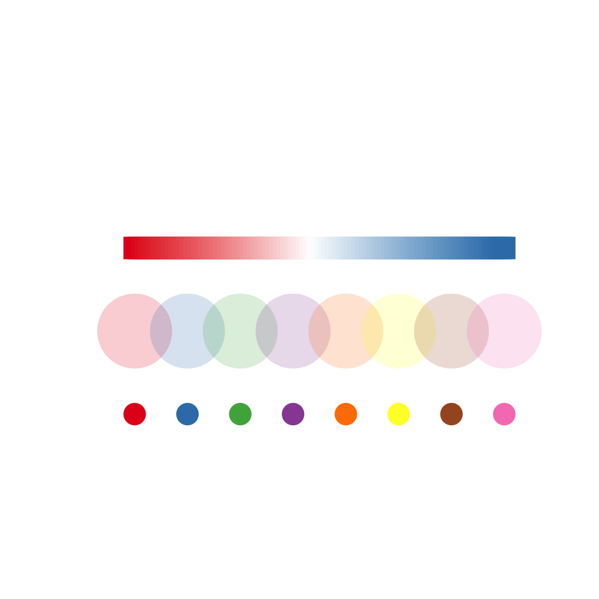

```r
library(RColorBrewer)
cc <- brewer.pal(8,'Set1') ## get color bar
plot(x=1:8, y=rep(1,8), pch=16, cex=3, col=cc,ylim=c(0,5),xlim=c(0,9),xlab='',ylab='',xaxt='n',yaxt='n',bty='n',xaxs='i',yaxs='i')
points(x=1:8, y=rep(2,8), pch=16, cex=10, col=grDevices::adjustcolor(cc,alpha=0.2),xpd=TRUE) ## color with transparent
cc1 <- colorRampPalette(c(cc[1],'white',cc[2]))(100)
points(x=seq(1,8,length.out=100), y=rep(3,100), pch=15, cex=3, col=cc1,xpd=TRUE) ## color with interpolation
```

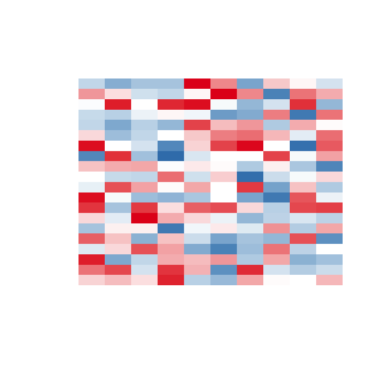

```r
cc <- brewer.pal(8,'Set1') ## get color bar
mat1 <- matrix(rnorm(0,1,n=200),nrow=10)
cc <- colorRampPalette(c(cc[2],'white',cc[1]))(100) ## color bar, blue->red
bb <- seq(-2,2,length.out=101) ## matched value breaks, length must be one longer than the color bar
image(mat1,col=cc,breaks=bb,xaxt='n',yaxt='n',bty='n') ## this is the start to create some plots like heatmap
```

### Demo1: create DNA double helix

Prepare the color code used here.

```r
col_DNA <- brewer.pal(8,'Set1')[2]
# A-green, T-red, C-yellow, G-blue
col_ATCG <- c(brewer.pal(8,'Accent')[1],brewer.pal(11,'Set3')[4],brewer.pal(11,'Set3')[2],brewer.pal(11,'Paired')[1])
```

First calculate the position for X and Y if we plan to draw four units of DNA.

```r
DNA_length <- 4 ## the code only applies when DNA_length%%2==0, if DNA_length%%2==1, need to modify
x <- seq(-DNA_length*pi/2,DNA_length*pi/2,length.out=1000) ##
y1 <- cos(x) ## backbone up
y2 <- cos(x+pi) ## backbone down
# get the position of nucleotides
xx <- seq(DNA_length*pi/2,-DNA_length*pi/2,length.out = DNA_length*5+1);
xx <- xx+(xx[2]-xx[1])/2
# remove the first and the lines in the boundary region
xx <- setdiff(xx,c(xx[c(1:DNA_length)*5-2],min(xx)))
```

Draw the backbones first, consider that backbones need to display at the upper level of the figure, so we only draw one here in order to get the figure size. Here, set `xlab`,`ylab`,`xaxt`,`yaxt`,`bty` to remove axis and background lines. `segments` is used to draw lines with calculated start and end position. `lines` is used to draw lines with continous position.

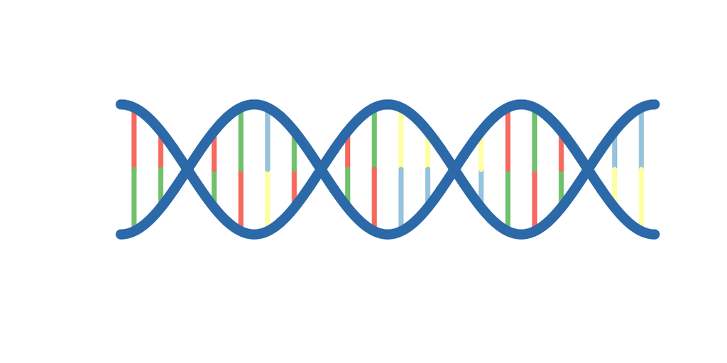

```r
plot(y1~x,pch=16,type='l',xlab='',ylab='',xaxt='n',yaxt='n',main='',bty='n',col='white')
for(i in 1:length(xx)){
    ybottom <- cos(xx[i]) # ybottom position
    ytop    <- cos(xx[i]+pi) # yup position
    rr <- sample(1:4,1) ## ATCG, random select one pair
    if(rr==1){
      segments(y0=ybottom,y1=0,x0=xx[i],x1=xx[i],col=col_ATCG[1],lwd=4) ## A-T
      segments(y0=0,y1=ytop,x0=xx[i],x1=xx[i],col=col_ATCG[2],lwd=4)
    }
    if(rr==2){
      segments(y0=ybottom,y1=0,x0=xx[i],x1=xx[i],col=col_ATCG[2],lwd=4) ## T-A
      segments(y0=0,y1=ytop,x0=xx[i],x1=xx[i],col=col_ATCG[1],lwd=4)
    }
    if(rr==3){
      segments(y0=ybottom,y1=0,x0=xx[i],x1=xx[i],col=col_ATCG[3],lwd=4) ## C-G
      segments(y0=0,y1=ytop,x0=xx[i],x1=xx[i],col=col_ATCG[4],lwd=4)
    }
    if(rr==4){
      segments(y0=ybottom,y1=0,x0=xx[i],x1=xx[i],col=col_ATCG[4],lwd=4) ## G-C
      segments(y0=0,y1=ytop,x0=xx[i],x1=xx[i],col=col_ATCG[3],lwd=4)
    }
  }
lines(y1~x,pch=16,lwd=8,col=col_DNA)
lines(y2~x,pch=16,lwd=8,col=col_DNA)
```

Task1: modifiy the script to draw for `DNA_length` with odd number (e.g `DNA_length=5`).

### Demo2: create network plot

Lots of tools have been created to draw fancy network figures, such as cytoscape, visNetwork, networkD3. Those tools are very useful for server usage or exquisite visualization. For R, igraph provides lot of layout functions for network display and the output of those functions are the positions of nodes in the figure. A similar tutorial could be found [here](https://kateto.net/wp-content/uploads/2016/06/Polnet%202016%20R%20Network%20Visualization%20Workshop.pdf).

Firstly, random generate a network.

```r
source_list <- paste0('Driver',1:5)
target_list <- paste0('Target',1:600)
random_net  <- do.call(rbind,lapply(source_list,function(x){
  r1 <- 0.03*sample(1:10,1) ##target Vs. not target
  w1 <- sample(c(0,1),length(target_list),prob=c(1-r1,r1),replace=TRUE)
  x1 <- cbind(x,target_list[which(w1==1)])
  r1 <- 0.5 ##negative target Vs. positive target
  t1 <- sample(c(-1,1),nrow(x1),prob=c(1-r1,r1),replace=TRUE)
  x2 <- cbind(x1,t1)
}))
random_net <- as.data.frame(random_net,stringsAsFactors=FALSE)
names(random_net) <- c('Driver','Target','sign')
```

Secondly, display the network by `plot.igraph()`. I’d like to save the position for each point into a variable first and then put it into `plot.igraph`.

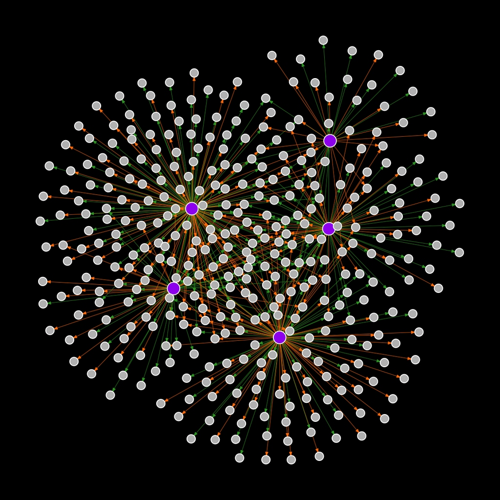

```r
# color code
library(RColorBrewer)
pos_col <- brewer.pal(12,'Paired')[8];
neg_col <- brewer.pal(12,'Paired')[4];
#
library(igraph)
gr <- graph.data.frame(random_net)
par(bg = 'black');par(mar=c(1,1,1,1))

## try the following layout
layout_pos <- layout_nicely(gr) #
layout_pos <- layout_with_dh(gr) #
layout_pos <- layout_with_graphopt(gr) #
layout_pos <- layout_with_kk(gr) #
layout_pos <- layout_with_lgl(gr) #
## the following layout seems not fitable for this network
#layout_pos <- layout_as_star(gr)
#layout_pos <- layout_as_tree(gr)
#layout_pos <- layout_in_circle(gr)
#layout_pos <- layout_on_grid(gr)
#layout_pos <- layout_on_sphere(gr)
#layout_pos <- layout_with_fr(gr)
#layout_pos <- layout_with_gem(gr)
#layout_pos <- layout_with_mds(gr)
plot(gr,
     edge.arrow.mode=2,
     edge.arrow.size=0.2,
     edge.width=0.4,
     edge.color=ifelse(E(gr)$sign==1,pos_col,neg_col),
     vertex.label='',
     vertex.frame.color="white",
     vertex.size=ifelse(V(gr)$name %in% source_list,6,4),
     vertex.color=ifelse(V(gr)$name %in% source_list,'purple','grey'),
     layout=layout_pos)
```

For a driver, try to display its subnetwork by igraph.

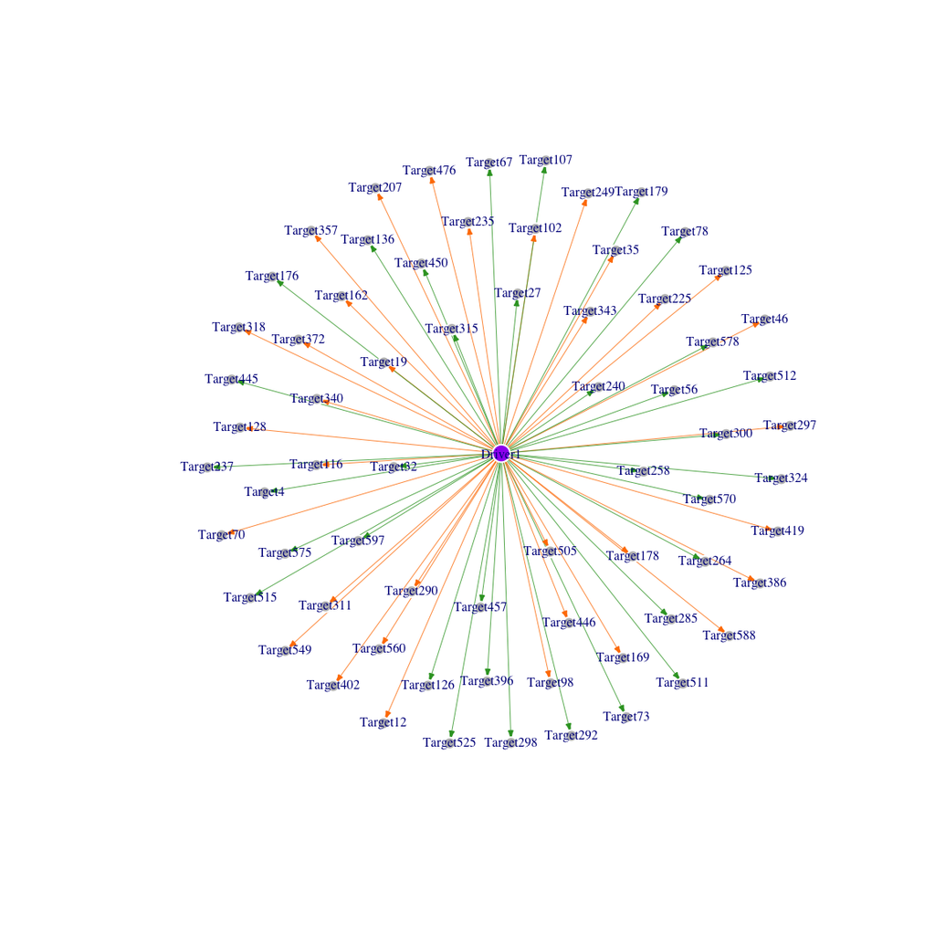

```r
gr <- subgraph(gr,v=ego(gr,nodes='Driver1')[[1]])
layout_pos <- layout_nicely(gr)
plot(gr,
     edge.arrow.mode=2,
     edge.arrow.size=0.2,
     edge.width=0.4,
     edge.color=ifelse(E(gr)$sign==1,pos_col,neg_col),
     vertex.label=V(gr)$name,vertex.label.cex=0.5,
     vertex.frame.color="white",
     vertex.size=ifelse(V(gr)$name %in% source_list,6,4),
     vertex.color=ifelse(V(gr)$name %in% source_list,'purple','grey'),
     layout=layout_pos)
```

Well, I don’t like it because of the label display, so I decide to create the plot without igraph (sometimes it is not necessary to do so). The complicated function could be found in my NetBID2 R package, `draw.targetNet()`. Here, I only use some of the code for sharing the experience.

Firstly, borrow a function `t2xy()` from `pie()` to get the position of each point in a circle.

```r
t2xy <- function(tt,radius=1) {
  t2p <- pi*2 * tt
  list(x = radius * cos(t2p), y = radius * sin(t2p))
}
library(plotrix) ## for draw.ellipse()
# get the network from graph object
net1 <- igraph::as_data_frame(gr,what='edges')
target_list <- sort(unique(net1$to))
target_sign <- net1$sign;
names(target_sign) <- net1$to;
target_sign <- target_sign[target_list]
tt <- seq(0,1,length.out = length(target_list)+1)[-1] ## 0,1 will be the same point, so the length should add 1 and remove the first one
net1_pos <- t2xy(tt,radius=0.7)
```

Then, if the position of the target is calculated, creating a plot is not difficult. Add edges with start and end position, add nodes with the end position.

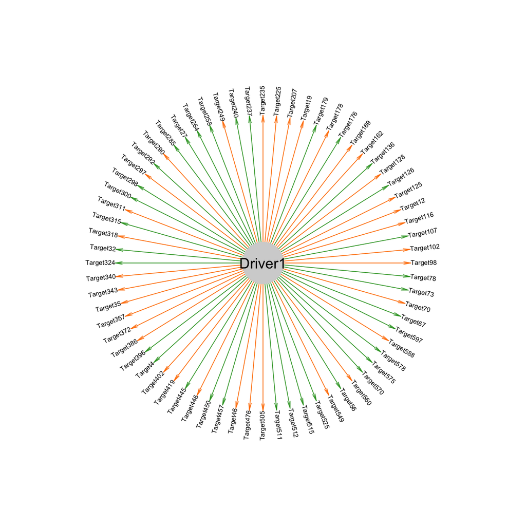

```r
# plot an empty figure
par(mar=c(2,2,2,2))
plot(1,xlim=c(-1,1),ylim=c(-1,1),bty='n',col='white',xlab="",ylab="",xaxt='n',yaxt='n')
# add edges
graphics::arrows(x0=0,y0=0,x1=net1_pos$x,y1=net1_pos$y,col=ifelse(target_sign==1,pos_col,neg_col),lwd=0.8,angle=10,length=0.08,xpd=TRUE);
# add nodes
for(i in 1:length(target_list)){
  text(net1_pos$x[i],net1_pos$y[i],target_list[i],cex=0.3+10/length(target_list),
     srt=180*atan(net1_pos$y[i]/net1_pos$x[i])/pi,adj=ifelse(net1_pos$x[i]>0,0,1),
     xpd=TRUE)
}
draw.ellipse(0,0,a=0.1,b=0.1,col='light grey',border=NA)
text(0,0,'Driver1',adj=0.5,xpd=TRUE,cex=1)
```

The position and the direction of the text, adjusted by `srt` and `adj`, `srt` is the string rotation in degrees and is calculated by:

```r
i <- 1
use_srt <- 180*atan(net1_pos$y[i]/net1_pos$x[i])/pi
```

In R, the conversion between degree and radians is:

- radians = degree*pi/180
- degree = 180*radians/pi

The above script is just a demo to show how to think to create such a plot, sometimes need to adjust it to be more beautiful.

### Demo3: adjust a figure

In Rstudio, there is a cheat sheet explaining the basic parameters used to adjust a graph: [How big is your graph?](https://github.com/rstudio/cheatsheets/raw/master/how-big-is-your-graph.pdf)

The following parameters need to be very familiar to create a plot, the following is a demo try to include those parameters.

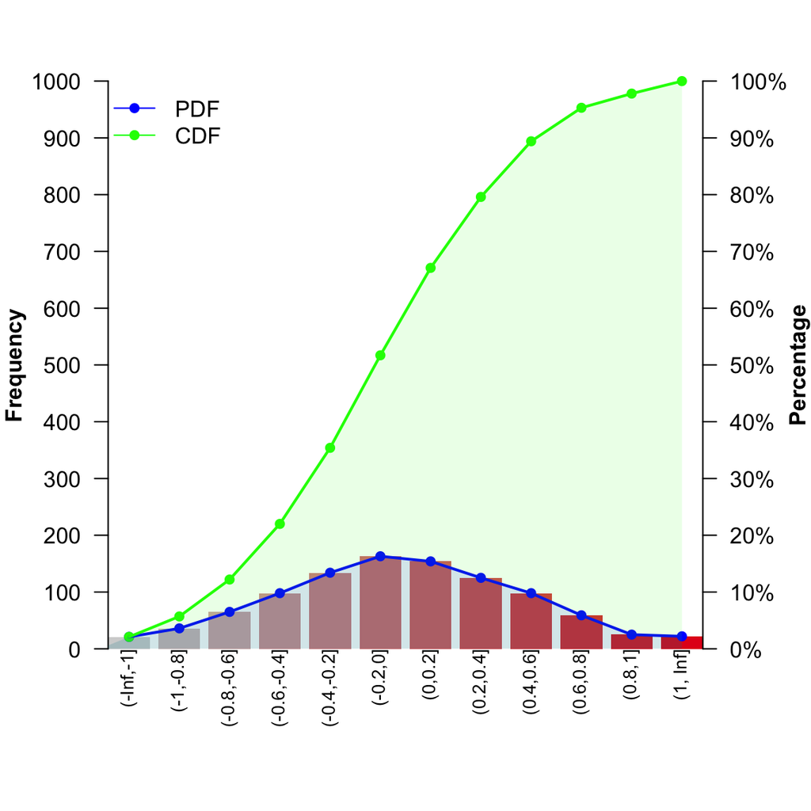

```r
par(mar=c(6,4,3,4))
# par(XXX=XXX) is used to set the parameters in par()
x <- rnorm(mean=0,sd=0.5,n=1000) ## random generate a numeric vector
n_bar <- 11
x1 <- cut(x,breaks=c(-Inf,seq(-1,1,length.out=n_bar),Inf))
x2 <- table(x1)/length(x1)
cc <- brewer.pal(8,'Set1')
cc <- colorRampPalette(c('light grey',cc[1]))(length(x2)) ## color bar
a <- barplot(x2,bty='n',xlab="",ylab="",xaxt='n',yaxt='n',xaxs='i',yaxs='i',border=NA,col=cc,ylim=c(0,1))
# barplot will return the position for each bar
# xlim, ylim
# bty
# xlab, ylab
# xaxt, yaxt
# xaxs, yaxs; default is "r", and will extend 4% at each end. try setting and print par()$usr
# border
pp <- par()$usr
# all values in par() could be extracted and used ! par()$usr is the position for the left, right ,bottom and top of the figure
text(a,pp[3],levels(x1),xpd=TRUE,adj=1,cex=0.8,srt=90)
# srt
# xpd
# adj
axis(side=2,at=seq(0,1,length.out = 11),labels=seq(0,1,length.out = 11)*length(x1),las=2)
axis(side=4,at=seq(0,1,length.out = 11),labels=paste0(seq(0,100,length.out = 11),'%'),las=2)
mtext(side=2,line=3,'Frequency',xpd=TRUE,font=2)
mtext(side=4,line=3,'Percentage',xpd=TRUE,font=2)
# side
# las
# font
x3 <- cumsum(x2)
points(x=a,y=x2,pch=16,xpd=TRUE,cex=1,col='blue')
points(x=a,y=x3,pch=16,xpd=TRUE,cex=1,col='green')
# pch
# xpd
# cex
lines(x2~a,lwd=2,lty=1,col='blue')
lines(x3~a,lwd=2,lty=1,col='green')
# lwd
# lty
# col
legend('topleft',col=c('blue','green'),lty=1,legend=c('PDF','CDF'),bty='n',border=NA,pch=16)
# border, lty
polygon(x=c(a,max(a),0),y=c(x3,0,0),col=grDevices::adjustcolor('green',alpha=0.1),border=NA)
polygon(x=c(a,max(a),0),y=c(x2,0,0),col=grDevices::adjustcolor('blue',alpha=0.1),border=NA)
```

```r
# for polygon, just need to get the position for the margin lines
## finally have a look at the parameters in par(), this object saves the current settings, which is very useful for position calculation.
print(str(par()))
```

```
## List of 72
##  $ xlog     : logi FALSE
##  $ ylog     : logi FALSE
##  $ adj      : num 0.5
##  $ ann      : logi TRUE
##  $ ask      : logi FALSE
##  $ bg       : chr "white"
##  $ bty      : chr "o"
##  $ cex      : num 1
##  $ cex.axis : num 1
##  $ cex.lab  : num 1
##  $ cex.main : num 1.2
##  $ cex.sub  : num 1
##  $ cin      : num [1:2] 0.15 0.2
##  $ col      : chr "black"
```

[output cut: 59 more lines]

Next, there are some functions and parameters not common used by also very important, especially to calculate size for the plot. Let’s create a plot with 6 inch width and 8 inch height.

In R, some units conversions:

1 inch = 72 bp (could set by ps)

1 inch = 2.54 cm

lwd=1 –> 1/96 inch

cex=1 –> For pch in 0:25 the default size is about 75% of the character height (`par()$cin[2]`, `cin` is read-only arguments).

ps: font point size (roughly 1bp=1/72 inch); text size=ps*cex. Default `par()$ps=12`.

Following are some functions to convert between position and inch. Remember that x and y may have different ratio.

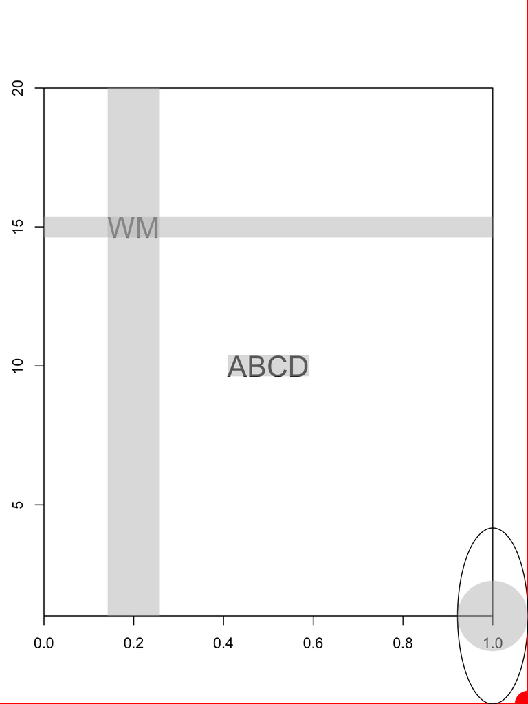

```r
par.pos2inch <- function(){
  user.range <- par("usr")[c(2,4)] - par("usr")[c(1,3)]
  region.pin <- par("pin")
  return(region.pin/user.range)
}
par.inch2pos <- function(){return(1/par.pos2inch())}
par.char2inch <- function(){return(par()$cin)} ## letter W
par.lineHeight2inch <- function(){
  lheight <- par()$lheight
  y1 <- par.char2inch()[2]*lheight ## line height in inches
  y1
}
par.char2pos <- function(){par()$cxy}
## set margin to inches
bottom_margin <- 1; right_margin <- 0.4
top_margin <- 1; left_margin <- 0.5;
par(mai=c(bottom_margin,left_margin,top_margin,right_margin)) ## bottom 1 inch margin, right 0.5 inch margin
# right_margin*par.inch2pos()[1] is the x-axis position for the margin
# bottom_margin*par.inch2pos()[2] is the y-axis position for the margin

# plot
plot(1,xlim=c(0,1),ylim=c(1,20),xaxs='i',yaxs='i',xlab='',ylab='',cex=1,xpd=TRUE,col='white') ## create an empty plot
# get to know the relation between xy position and inch
points(x=1+right_margin*par.inch2pos()[1],y=1-bottom_margin*par.inch2pos()[2],pch=16,cex=4,xpd=TRUE,col='red') ## margin point, set xpd=TRUE otherwise will not displayed
abline(v=1+right_margin*par.inch2pos()[1],lwd=2,col='red',xpd=TRUE) ## margin line, set xpd=TRUE otherwise will not displayed
abline(h=1-bottom_margin*par.inch2pos()[2],lwd=2,col='red',xpd=TRUE) ## margin line, set xpd=TRUE otherwise will not displayed
draw.ellipse(x=1,y=1,a=right_margin*par.inch2pos()[1],b=bottom_margin*par.inch2pos()[2],xpd=TRUE)

# get to know the relation between character width, height and position
test_char <- 'ABCD'; test_cex = 2;
char_width  <- strwidth(test_char,units='user',cex=test_cex) ## units to 'user' means the value in x axis
char_height <- strheight(test_char,units='user',cex=test_cex) ##
text(0.5,10,test_char,cex=test_cex)
rect(xleft = 0.5-char_width/2,xright=0.5+char_width/2,ybottom=10-char_height/2,ytop=10+char_height/2,
     col=grDevices::adjustcolor('grey',alpha=0.5),border=NA) ## draw background rectangle for the text

# get to know the relation between cex, xy-position and inch
p1 <- par.char2inch()[2]*0.75 ## inch length for cex=1 with pch=16, is 75% of the character height
points(x=1,y=1,pch=16,xpd=TRUE,cex=right_margin*2*2/p1,col=grDevices::adjustcolor('grey',alpha=0.5)) ## to fullfill right_margin*2, with two sides

# get to know the relation between character width, height, lwd and inch
test_char <- 'WM'; test_cex = 2;
char_width  <- strwidth(test_char,units='user',cex=test_cex) ## units to 'user' means the value in x axis
char_height <- strheight(test_char,units='user',cex=test_cex) ##
text(0.2,15,test_char,cex=test_cex)
abline(h=15,col=grDevices::adjustcolor('grey',alpha=0.5),lwd=char_height*par.pos2inch()[2]/(1/96)) ## 1 lwd --> 1/96 inch
abline(v=0.2,col=grDevices::adjustcolor('grey',alpha=0.5),lwd=char_width*par.pos2inch()[1]/(1/96))
```

```r
# get to know the relation between strheight, strwidth, and par()$cin
print(par()$lheight) ## default is one line height, defined by par()$cin[2], 0.2 inches
```

```
## [1] 1
```

```r
strheight('W\n',units='inches')-strheight('W',units='inches') ## equals to par()$cin[2]
```

```
## [1] 0.2
```

```r
strheight(sprintf('%s\n',LETTERS),units='inches')-strheight(sprintf('%s',LETTERS),units='inches')## all equals to par()$cin[2]
```

```
##  [1] 0.2 0.2 0.2 0.2 0.2 0.2 0.2 0.2 0.2 0.2 0.2 0.2 0.2 0.2 0.2 0.2 0.2
## [18] 0.2 0.2 0.2 0.2 0.2 0.2 0.2 0.2 0.2
```

```r
# try to change lheight
par(lheight=2) ## if set to 2, the line height will be lheight*par()$cin[2]=0.4
strheight('W\n',units='inches')-strheight('W',units='inches') ## equals to par()$cin[2]
```

```
## [1] 0.4
```

```r
strheight(sprintf('%s\n',LETTERS),units='inches')-strheight(sprintf('%s',LETTERS),units='inches')## all equals to par()$cin[2]
```

```
##  [1] 0.4 0.4 0.4 0.4 0.4 0.4 0.4 0.4 0.4 0.4 0.4 0.4 0.4 0.4 0.4 0.4 0.4
## [18] 0.4 0.4 0.4 0.4 0.4 0.4 0.4 0.4 0.4
```

```r
# but strwidth differs a lot, try:
strwidth(LETTERS,units='inches')
```

```
##  [1] 0.11116536 0.11116536 0.12036133 0.12036133 0.11116536 0.10180664
##  [7] 0.12963867 0.12036133 0.04630534 0.08333333 0.11116536 0.09269206
## [13] 0.13883464 0.12036133 0.12963867 0.11116536 0.12963867 0.12036133
## [19] 0.11116536 0.10180664 0.12036133 0.11116536 0.15730794 0.11116536
## [25] 0.11116536 0.10180664
```

```r
strwidth('AB',units='inches')-strwidth('A',units='inches') # equals to strwidth('B',units='inches')
```

```
## [1] 0.1111654
```

Task2: modifiy the script in Demo2 and let the point size for the “Driver1” could match the text size of “Driver1”.

### Demo4: create a plot with multiple subgraphs

Then, we could try to create plots with subgraphs. Let’s try to create heatmap (well, no need to do so ….).

Prepare the data.

```r
cc <- brewer.pal(8,'Set1') ## get color bar
mat1 <- matrix(c(rnorm(1,0.5,n=80),rnorm(-1,0.5,n=120)),nrow=20,byrow=TRUE) ## 20 genes in 10 samples
mat2 <- matrix(c(rnorm(-1,0.5,n=150),rnorm(1,0.5,n=150)),nrow=20,byrow=TRUE) ## 20 genes in 15 samples
colnames(mat1) <- sprintf('Sample%s',1:10)
colnames(mat2) <- sprintf('Sample%s',10+1:15)
rownames(mat1) <- rownames(mat2) <- sprintf('Gene%s',1:20)
mat_all <- cbind(mat1,mat2)
cc <- colorRampPalette(c(cc[2],'white',cc[1]))(100) ## color bar
bb <- c(min(mat_all)-1,seq(-2,2,length.out=99),1+max(mat_all)) ## matched value breaks, length must be one longer than the color bar
# reorder the matrix
h1 <- hclust(dist(mat_all))
h2 <- hclust(dist(t(mat_all)))
o1 <- h1$order
o2 <- h2$order
mat_all <- mat_all[o1,o2]
```

I like to use `graphics::layout` to design the figure. Also for simple usage, could directly use `par(mfrow=XX,mfcol=XX)`.

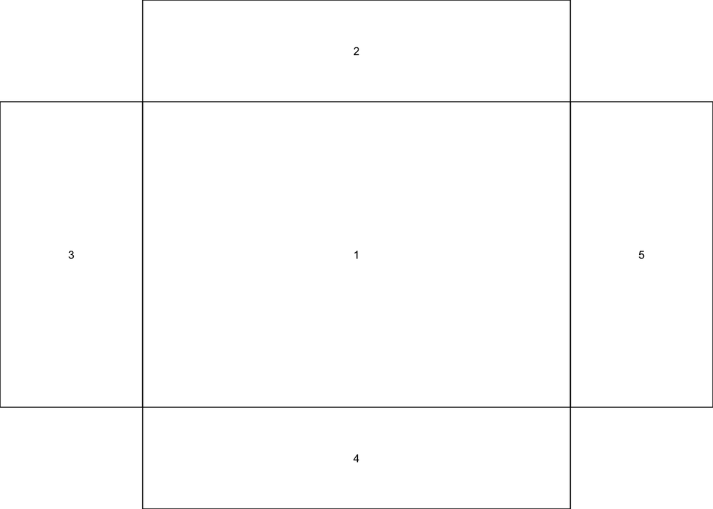

```r
m1 <- matrix(c(0,2,2,2,0,3,1,1,1,5,3,1,1,1,5,3,1,1,1,5,0,4,4,4,0),nrow=5,byrow=TRUE) ## tip: sometimes could design it in excel first and then read in into R
## then, draw 1,2,3,4,5 sub-figures by order. 0 could be used to represent no figure in the area
n1 <- layout(m1)
layout.show(n1)
```

Then,draw as follows,

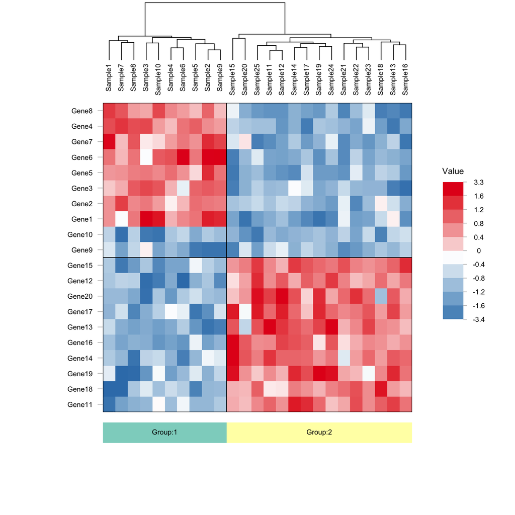

```r
layout(m1)
# 1. image plot
par(mar=c(0,0,0,0))
draw_mat <- t(mat_all)
image(draw_mat,col=cc,breaks=bb,xlab='',ylab='',xaxt='n',yaxt='n',bty='n',xaxs='i',yaxs='i')
pp <- par()$usr ## get to know the xy position of the figure
x_line_pos <- seq(pp[1],pp[2],length.out=nrow(draw_mat)+1) ## x position for vertical line
y_line_pos <- seq(pp[3],pp[4],length.out=ncol(draw_mat)+1) ## y position for each horizon line
x_mid_pos  <- x_line_pos[1:(length(x_line_pos)-1)]/2+x_line_pos[2:length(x_line_pos)]/2 ## x position for column mid position
y_mid_pos  <- y_line_pos[1:(length(y_line_pos)-1)]/2+y_line_pos[2:length(y_line_pos)]/2 ## y position for row mid position
# try to draw line to seperate groups
g1 <- cutree(h1,k=2) ## try to change k values
g2 <- cutree(h2,k=2)
w1 <- cumsum(table(g1[rownames(mat_all)])[unique(g1[rownames(mat_all)])]) ## get to know the seperation number, must be in the original order
w2 <- cumsum(table(g2[colnames(mat_all)])[unique(g2[colnames(mat_all)])])
abline(v=x_line_pos[c(1,w2+1)],xpd=TRUE) ## draw the line
abline(h=y_line_pos[c(1,w1+1)],xpd=TRUE)

# 2. dendrogram at the top
par(mar=c(0,0,0,0))
hcd <- as.dendrogram(h2)
plot(hcd,type = "rectangle", ylab = "",xlim=c(0.5,length(h2$order)+0.5),xaxs='i',yaxs='i',yaxt='n',
     ylim=c(-8,0.5+max(h2$height)))
## X: 0.5 adjustment for start and end position; Y: real range should be c(0,max(h2$height)), leave some place to draw rectangle + sample label (if leaflab!='n')
## for the dendrogram, lots of modifications could be used, try change the type

# 3. at the left to add gene name
plot(1,col='white',xlab='',ylab='',xaxt='n',yaxt='n',bty='n',xaxs='i',yaxs='i',ylim=c(0,nrow(mat_all)),xlim=c(0,1))
text(x=0.9,y=c(1:nrow(mat_all))-0.5,rownames(mat_all),adj=1)
# add tick
segments(x0=0.95,x1=1,y0=c(1:nrow(mat_all))-0.5,y1=c(1:nrow(mat_all))-0.5,col='grey')

# 4. at the bottom to add bar to indicate sample group
cc_pair <- brewer.pal(11,'Set3')
plot(1,col='white',xlab='',ylab='',xaxt='n',yaxt='n',bty='n',xaxs='i',yaxs='i',xlim=c(0,ncol(mat_all)),ylim=c(0,1))
rect(xleft=c(0,w2[1:(length(w2)-1)]),xright=w2,ybottom=0.7,ytop=0.9,col=cc_pair[1:length(w2)],border=NA)
# add group name
text(c(0,w2[1:(length(w2)-1)])/2+w2/2,y=0.8,sprintf("Group:%s",names(w2)),adj=0.5)

# 5. at the right to add color bar for values in the image
plot(1,col='white',xlab='',ylab='',xaxt='n',yaxt='n',bty='n',xaxs='i',yaxs='i',xlim=c(0,1),ylim=c(0,1))
yy_pos <- seq(0.3,0.7,length.out=10)
ddy <- yy_pos[2]-yy_pos[1]
bb_u   <- round(seq(1,length(bb),length.out=11))
cc_u   <- cc[bb_u[2:length(bb_u)]-1]
rect(xleft=rep(0.3,11),xright=rep(0.5,11),
     ybottom=yy_pos,
     ytop=yy_pos+ddy,
     col=cc_u,xpd=TRUE,border=NA)
text(0.65,c(yy_pos,max(yy_pos)+ddy),round(bb[bb_u],1),adj=0.5)
text(0.4,0.78,'Value',cex=1.2)
# add tick
segments(x0=0.5,x1=0.53,y0=c(yy_pos,max(yy_pos)+ddy),y1=c(yy_pos,max(yy_pos)+ddy),col='grey')
```

Tips: when trying to draw en empty graph, I like to use `plot()` rather than `plot.new()`. In plot, I could set `xaxs='i',yaxs='i'` and set `xlim`, `ylim` to proper values that could make position easy to calculate between different sub-figures.

### Demo5: create sankey diagrams and circos

There are already lots of packages to create Sankey diagrams and circos. Well, here just to show how it works.

For the Sankey diagrams, need to write a function to calculate positions for the curve with a start and an end point. It is very simple, just the modificiation of sin curve.

```r
curve_sankey <- function (x0, x1, y0, y1,nsteps = 100){
    xx <- seq(-pi/2, pi/2, length.out = nsteps)
    yy <- y0 + (y1 - y0) * (sin(xx) + 1)/2
    xx <- seq(x0, x1, length.out = nsteps)
    list(x=xx,y=yy)
}
```

Firstly, get to know how to draw those curves.

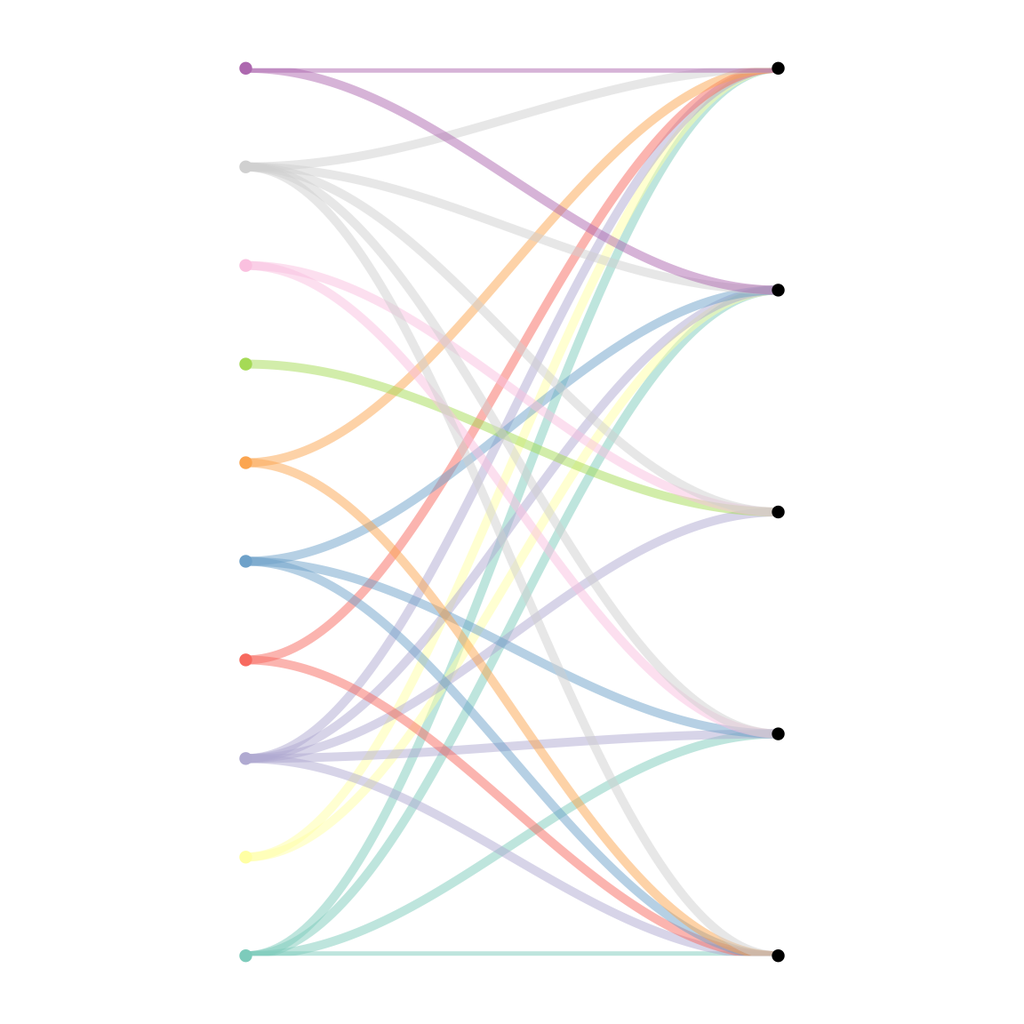

```r
layout(1)
par(mar=c(2,2,2,2))
cc1 <- brewer.pal(11,'Set3')
plot(1,col='white',xlab='',ylab='',xaxt='n',yaxt='n',bty='n',xaxs='i',yaxs='i',xlim=c(0,1),ylim=c(0,1))
pos1 <- seq(0,1,length.out=10)
pos2 <- seq(0,1,length.out=5)
# random generate link
rand_link <- lapply(pos1,function(x)sample(1:length(pos2),sample(1:5)))
for(i in 1:length(pos1)){
  for(j in 1:length(rand_link[[i]])){
      curve_pos <- curve_sankey(x0=0.2,y0=pos1[i],x1=0.8,y1=pos2[rand_link[[i]][j]])
      lines(curve_pos,col=adjustcolor(cc1[i],alpha=0.5),lwd=5)
  }
}
points(x=rep(0.2,length.out=length(pos1)),y=pos1,pch=16,col=cc1,xpd=TRUE)
points(x=rep(0.8,length.out=length(pos2)),y=pos2,pch=16,col='black',xpd=TRUE)
```

Secondly, try to draw the sandkey diagrams.

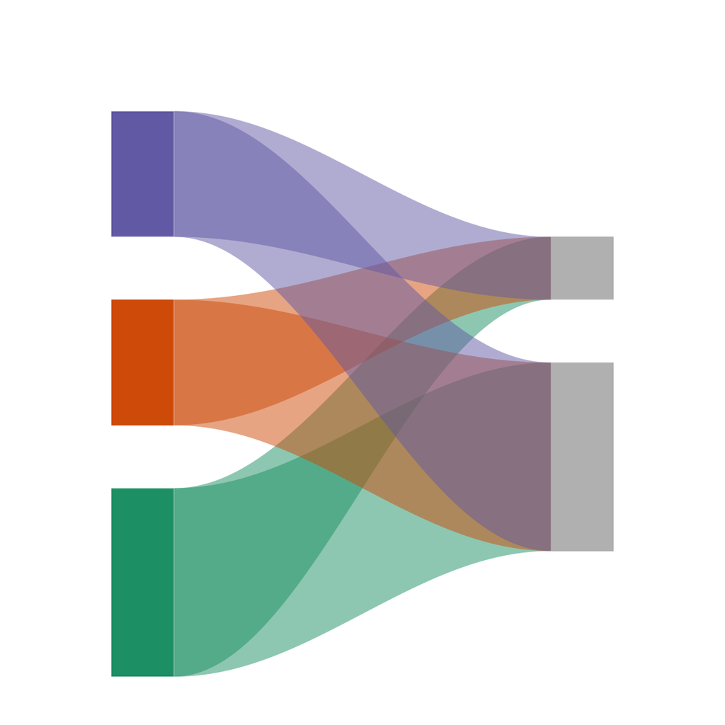

```r
layout(1)
par(mar=c(2,2,2,2))
cc1 <- brewer.pal(8,'Dark2')
plot(1,col='white',xlab='',ylab='',xaxt='n',yaxt='n',bty='n',xaxs='i',yaxs='i',xlim=c(0,1),ylim=c(0,1))
pos1_bottom <- c(0,0.4,0.7)
pos1_up <- c(0.3,0.6,0.9)
pos2_bottom <- c(0.2,0.6)
pos2_up <- c(0.5,0.7)
rect(xleft=0.1,xright=0.2,ybottom=pos1_bottom,ytop=pos1_up,pch=16,col=cc1,border=NA)
rect(xleft=0.8,xright=0.9,ybottom=pos2_bottom,ytop=pos2_up,pch=16,col='grey',border=NA)
for(i in 1:length(pos1_up)){
  for(j in 1:length(pos2_up)){
      curve_pos1 <- curve_sankey(x0=0.2,y0=pos1_up[i],x1=0.8,y1=pos2_up[j])
      curve_pos2 <- curve_sankey(x0=0.2,y0=pos1_bottom[i],x1=0.8,y1=pos2_bottom[j])
      polygon(x=c(curve_pos1$x,rev(curve_pos2$x)),y=c(curve_pos1$y,rev(curve_pos2$y)),col=adjustcolor(cc1[i],alpha=0.5),border=NA)
  }
}
```

```r
curve_circos <- function (x0, x1, y0, y1,nsteps = 100){
    tt <- seq(0, 1, 1/nsteps)
    xx <- (1 - tt)^2 * x0 + tt^2 * x1
    yy <- (1 - tt)^2 * y0 + tt^2 * y1
    list(x=xx,y=yy)
}
```

Firstly, get to know how to draw those curves.

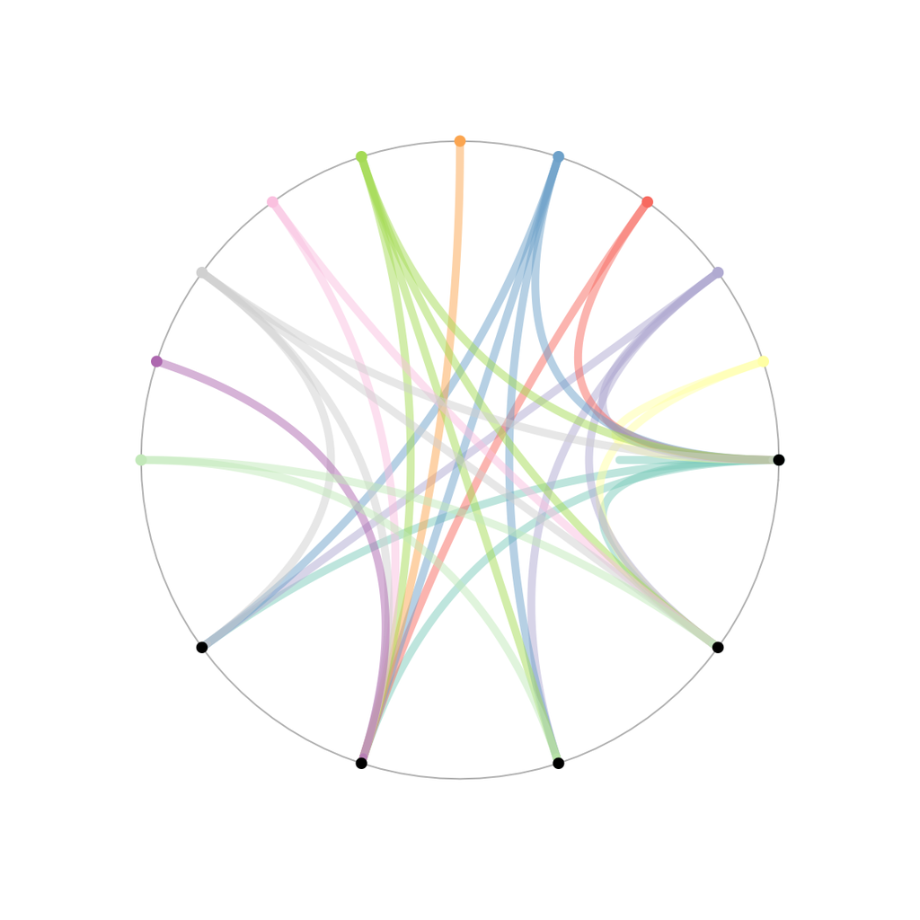

```r
layout(1)
par(mar=c(2,2,2,2))
cc1 <- brewer.pal(11,'Set3')
plot(1,col='white',xlab='',ylab='',xaxt='n',yaxt='n',bty='n',xaxs='i',yaxs='i',xlim=c(-1,1),ylim=c(-1,1))
draw.ellipse(0,0,a=0.8,b=0.8,border='grey')
pos1 <- t2xy(seq(0,0.5,length.out=11),radius = 0.8)
pos2 <- t2xy(seq(0.6,1,length.out=5),radius = 0.8)
# random generate link
rand_link <- lapply(pos1$x,function(x)sample(1:length(pos2$x),sample(1:4)))
for(i in 1:length(pos1$x)){
  for(j in 1:length(rand_link[[i]])){
      curve_pos <- curve_circos(x0=pos1$x[i],y0=pos1$y[i],x1=pos2$x[rand_link[[i]][j]],y1=pos2$y[rand_link[[i]][j]])
      lines(curve_pos,col=adjustcolor(cc1[i],alpha=0.5),lwd=5)
  }
}
points(x=pos1$x,y=pos1$y,pch=16,col=cc1,xpd=TRUE)
points(x=pos2$x,y=pos2$y,pch=16,col='black',xpd=TRUE)
```

Secondly, try to draw the circos.

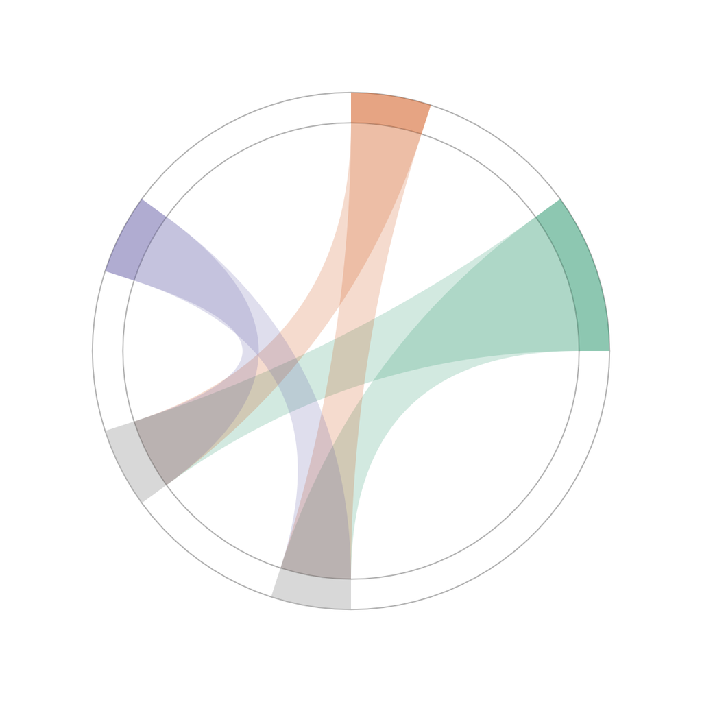

```r
layout(1)
par(mar=c(2,2,2,2))
cc1 <- brewer.pal(8,'Dark2')
plot(1,col='white',xlab='',ylab='',xaxt='n',yaxt='n',bty='n',xaxs='i',yaxs='i',xlim=c(-1,1),ylim=c(-1,1))
draw.ellipse(0,0,a=0.75,b=0.75,border='grey')
draw.ellipse(0,0,a=0.85,b=0.85,border='grey')
pos1_bottom <- c(0,0.2,0.4)
pos1_up <- c(0.1,0.25,0.45)
pos2_bottom <- c(0.55,0.7)
pos2_up <- c(0.6,0.75)
for(i in 1:length(pos1_bottom)){
 pos1_in <- t2xy(seq(pos1_bottom[i],pos1_up[i],length.out=100),radius = 0.75);
 pos1_out <- t2xy(seq(pos1_bottom[i],pos1_up[i],length.out=100),radius = 0.85)
 polygon(x=c(pos1_in$x,rev(pos1_out$x)),y=c(pos1_in$y,rev(pos1_out$y)),
         col=adjustcolor(cc1[i],alpha=0.5),border=NA)
}
for(i in 1:length(pos2_bottom)){
 pos2_in <- t2xy(seq(pos2_bottom[i],pos2_up[i],length.out=100),radius = 0.75);
 pos2_out <- t2xy(seq(pos2_bottom[i],pos2_up[i],length.out=100),radius = 0.85)
 polygon(x=c(pos2_in$x,rev(pos2_out$x)),y=c(pos2_in$y,rev(pos2_out$y)),
         col=adjustcolor('grey',alpha=0.5),border=NA)
}
for(i in 1:length(pos1_up)){
  for(j in 1:length(pos2_up)){
      curve_start <- t2xy(pos1_up[i],radius=0.75)
      curve_end <- t2xy(pos2_bottom[j],radius=0.75)
      curve_pos1 <- curve_circos(x0=curve_start$x,y0=curve_start$y,x1=curve_end$x,y1=curve_end$y)
      curve_start <- t2xy(pos1_bottom[i],radius=0.75)
      curve_end <- t2xy(pos2_up[j],radius=0.75)
      curve_pos2 <- curve_circos(x0=curve_start$x,y0=curve_start$y,x1=curve_end$x,y1=curve_end$y)
      pos1_in <- t2xy(seq(pos1_bottom[i],pos1_up[i],length.out=100),radius = 0.75);
      pos2_in <- t2xy(seq(pos2_bottom[j],pos2_up[j],length.out=100),radius = 0.75);
      polygon(x=c(pos1_in$x,curve_pos1$x,pos2_in$x,rev(curve_pos2$x)),
              y=c(pos1_in$y,curve_pos1$y,pos2_in$y,rev(curve_pos2$y)),
              col=adjustcolor(cc1[i],alpha=0.2),border=NA)
  }
}
```

Well, seems not very difficult, right ?

Remember that the key point is to calculate position !

Good Luck & Have Fun !